# Practica

Laura Chaparro

20/1/2022

#**Practica Penguins**

Cargamos las librerias y los datos a utilizar

```r
library(dplyr)
library(plyr)
```

```r
library(ggplot2)
library(palmerpenguins)
data(package = 'palmerpenguins')
```

Observamos los datos

```r
View(penguins)
View(penguins_raw)
str(penguins)
```

```
## tibble [344 x 8] (S3: tbl_df/tbl/data.frame)
##  $ species          : Factor w/ 3 levels "Adelie","Chinstrap",..: 1 1 1 1 1 1 1 1 1 1 ...
##  $ island           : Factor w/ 3 levels "Biscoe","Dream",..: 3 3 3 3 3 3 3 3 3 3 ...
##  $ bill_length_mm   : num [1:344] 39.1 39.5 40.3 NA 36.7 39.3 38.9 39.2 34.1 42 ...
##  $ bill_depth_mm    : num [1:344] 18.7 17.4 18 NA 19.3 20.6 17.8 19.6 18.1 20.2 ...
##  $ flipper_length_mm: int [1:344] 181 186 195 NA 193 190 181 195 193 190 ...
##  $ body_mass_g      : int [1:344] 3750 3800 3250 NA 3450 3650 3625 4675 3475 4250 ...
##  $ sex              : Factor w/ 2 levels "female","male": 2 1 1 NA 1 2 1 2 NA NA ...
##  $ year             : int [1:344] 2007 2007 2007 2007 2007 2007 2007 2007 2007 2007 ...
```

```r
summary(penguins)
```

```
##       species          island    bill_length_mm  bill_depth_mm
##  Adelie   :152   Biscoe   :168   Min.   :32.10   Min.   :13.10
##  Chinstrap: 68   Dream    :124   1st Qu.:39.23   1st Qu.:15.60
##  Gentoo   :124   Torgersen: 52   Median :44.45   Median :17.30
##                                  Mean   :43.92   Mean   :17.15
##                                  3rd Qu.:48.50   3rd Qu.:18.70
##                                  Max.   :59.60   Max.   :21.50
##                                  NA's   :2       NA's   :2
##  flipper_length_mm  body_mass_g       sex           year
##  Min.   :172.0     Min.   :2700   female:165   Min.   :2007
##  1st Qu.:190.0     1st Qu.:3550   male  :168   1st Qu.:2007
##  Median :197.0     Median :4050   NA's  : 11   Median :2008
##  Mean   :200.9     Mean   :4202                Mean   :2008
##  3rd Qu.:213.0     3rd Qu.:4750                3rd Qu.:2009
##  Max.   :231.0     Max.   :6300                Max.   :2009
##  NA's   :2         NA's   :2
```

##**Punto 1**

Número de individuos totales : **344**

```r
length(penguins$species)
```

```
## [1] 344
```

masculinos y femeninos por especie.

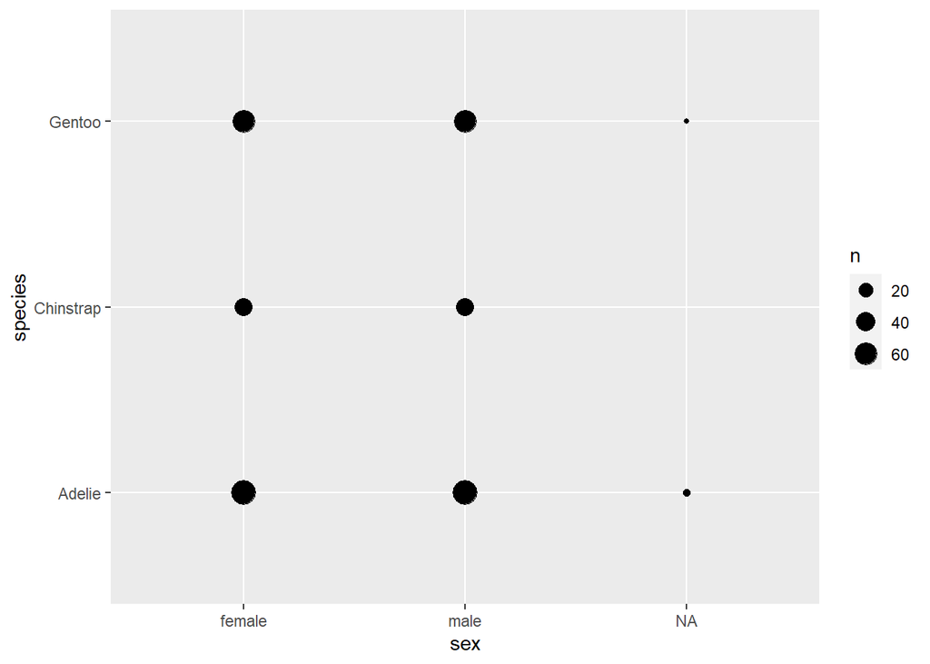

```r
ggplot(data = penguins)+
  geom_count(aes(x= sex, y = species))
```

```r
table(penguins$sex, penguins$species)
```

```
##
##          Adelie Chinstrap Gentoo
##   female     73        34     58
##   male       73        34     61
```

La media, desviación estándar, valor mínimo y máximo de la longitud y profundidad del pico, la longitud de la aleta y el tamaño

*Media*

```r
penguins <- na.omit(penguins)

tapply(penguins$bill_length_mm, penguins$species, mean)
```

```
##    Adelie Chinstrap    Gentoo
##  38.82397  48.83382  47.56807
```

```r
tapply(penguins$bill_depth_mm, penguins$species, mean)
```

```
##    Adelie Chinstrap    Gentoo
##  18.34726  18.42059  14.99664
```

```r
tapply(penguins$flipper_length_mm, penguins$species, mean)
```

```
##    Adelie Chinstrap    Gentoo
##  190.1027  195.8235  217.2353
```

```r
tapply(penguins$body_mass_g, penguins$species, mean)
```

```
##    Adelie Chinstrap    Gentoo
##  3706.164  3733.088  5092.437
```

*Desviacion estandar*

```r
tapply(penguins$bill_length_mm, penguins$species, sd)
```

```
##    Adelie Chinstrap    Gentoo
##  2.662597  3.339256  3.106116
```

```r
tapply(penguins$bill_depth_mm, penguins$species, sd)
```

```
##    Adelie Chinstrap    Gentoo
##  1.219338  1.135395  0.985998
```

```r
tapply(penguins$flipper_length_mm, penguins$species, sd)
```

```
##    Adelie Chinstrap    Gentoo
##  6.521825  7.131894  6.585431
```

```r
tapply(penguins$body_mass_g, penguins$species, sd)
```

```
##    Adelie Chinstrap    Gentoo
##  458.6201  384.3351  501.4762
```

*Valor maximo*

```r
tapply(penguins$bill_length_mm, penguins$species, max)
```

```
##    Adelie Chinstrap    Gentoo
##      46.0      58.0      59.6
```

```r
tapply(penguins$bill_depth_mm, penguins$species, max)
```

```
##    Adelie Chinstrap    Gentoo
##      21.5      20.8      17.3
```

```r
tapply(penguins$flipper_length_mm, penguins$species, max)
```

```
##    Adelie Chinstrap    Gentoo
##       210       212       231
```

```r
tapply(penguins$body_mass_g, penguins$species, max)
```

```
##    Adelie Chinstrap    Gentoo
##      4775      4800      6300
```

*Valor minimo*

```r
tapply(penguins$bill_length_mm, penguins$species, min)
```

```
##    Adelie Chinstrap    Gentoo
##      32.1      40.9      40.9
```

```r
tapply(penguins$bill_depth_mm, penguins$species, min)
```

```
##    Adelie Chinstrap    Gentoo
##      15.5      16.4      13.1
```

```r
tapply(penguins$flipper_length_mm, penguins$species, min)
```

```
##    Adelie Chinstrap    Gentoo
##       172       178       203
```

```r
tapply(penguins$body_mass_g, penguins$species, min)
```

```
##    Adelie Chinstrap    Gentoo
##      2850      2700      3950
```

##**Punto 2**

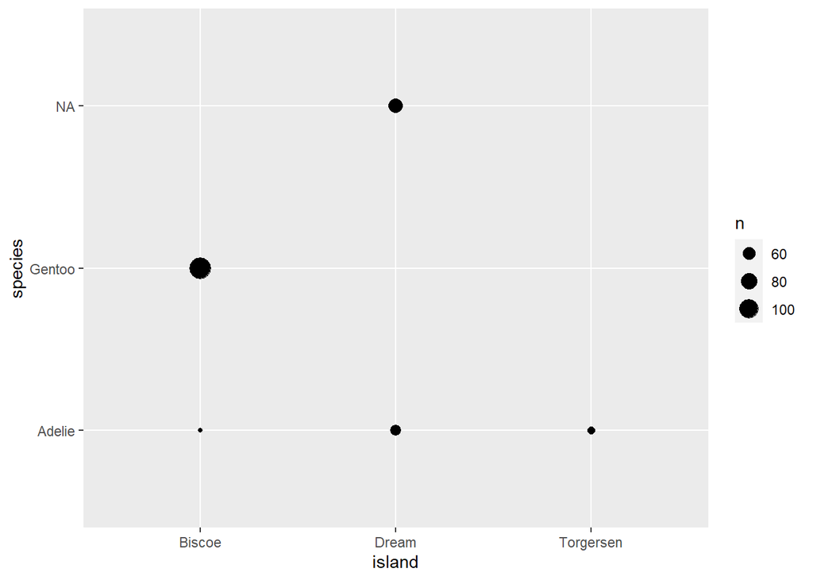

```r
penguins <- penguins %>%
  mutate(species = factor(species, levels = c('Adelie', 'Chinistrap', 'Gentoo')))

ggplot(data = penguins) +
  geom_count(aes(x = island, y = species))
```

```r
table(penguins$island, penguins$species )
```

```
##
##             Adelie Chinistrap Gentoo
##   Biscoe        44          0    119
##   Dream         55          0      0
##   Torgersen     47          0      0
```

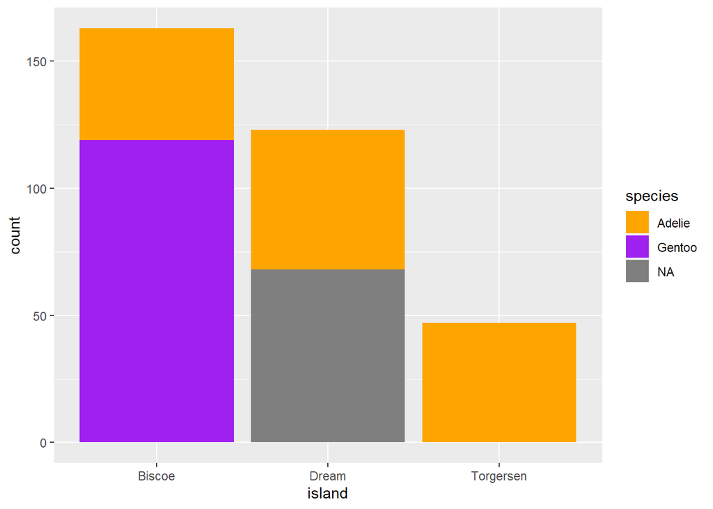

```r
ggplot(data = penguins) +
  geom_bar(aes(x = island, fill = species))+
  scale_fill_manual(values = c("orange", "purple", "blue"))
```

Contesta a las siguientes preguntas:

**1.**¿qué especie se ha muestreado en las tres islas?: **Adeline**

##**Punto 3**

Un gráfico multipanel de cajas y bigotes del tamaño de los pingüinos según su sexo, donde aparezca un panel para cada especie.

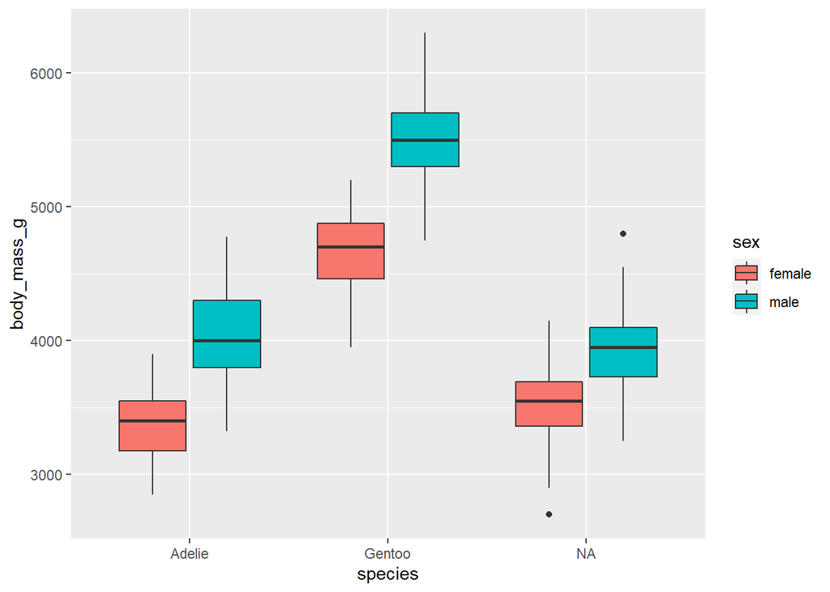

```r
ggplot(data = penguins)+
  geom_boxplot(aes(x = species, y = body_mass_g, fill = sex ))
```

Contesta a las siguientes preguntas:

**1.**¿qué especie tiene mayor tamaño? **Gentoo**

**2.**¿en qué especie las hembras y los machos tienen un tamaño más similar? **Chinistrap o (NA)**

```r
citation("ggplot2")
```

```
##
##
##   H. Wickham. ggplot2: Elegant Graphics for Data Analysis.
##   Springer-Verlag New York, 2016.
##
## A BibTeX entry for LaTeX users is
##
##   @Book{,
##     author = {Hadley Wickham},
##     title = {ggplot2: Elegant Graphics for Data Analysis},
##     publisher = {Springer-Verlag New York},
##     year = {2016},
##     isbn = {978-3-319-24277-4},
##     url = {https://ggplot2.tidyverse.org},
##   }
```

```r
citation("dplyr")
```

```
##
##
##   Hadley Wickham, Romain François, Lionel Henry and Kirill Müller
##   (2021). dplyr: A Grammar of Data Manipulation. R package version
##   1.0.7. https://CRAN.R-project.org/package=dplyr
##
## A BibTeX entry for LaTeX users is
##
##   @Manual{,
##     title = {dplyr: A Grammar of Data Manipulation},
##     author = {Hadley Wickham and Romain François and Lionel Henry and Kirill Müller},
##     year = {2021},
##     note = {R package version 1.0.7},
##     url = {https://CRAN.R-project.org/package=dplyr},
##   }
```

```r
citation("plyr")
```

```
##
##
##   Hadley Wickham (2011). The Split-Apply-Combine Strategy for Data
##   Analysis. Journal of Statistical Software, 40(1), 1-29. URL
##   http://www.jstatsoft.org/v40/i01/.
##
## A BibTeX entry for LaTeX users is
##
##   @Article{,
##     title = {The Split-Apply-Combine Strategy for Data Analysis},
##     author = {Hadley Wickham},
##     journal = {Journal of Statistical Software},
##     year = {2011},
##     volume = {40},
##     number = {1},
##     pages = {1--29},
##     url = {http://www.jstatsoft.org/v40/i01/},
##   }
```

```r
citation("palmerpenguins")
```

```
##
##
##   Horst AM, Hill AP, Gorman KB (2020). palmerpenguins: Palmer
##   Archipelago (Antarctica) penguin data. R package version 0.1.0.
##   https://allisonhorst.github.io/palmerpenguins/
##
## A BibTeX entry for LaTeX users is
##
##   @Manual{,
##     title = {palmerpenguins: Palmer Archipelago (Antarctica) penguin data},
##     author = {Allison Marie Horst and Alison Presmanes Hill and Kristen B Gorman},
##     year = {2020},
##     note = {R package version 0.1.0},
##     url = {https://allisonhorst.github.io/palmerpenguins/},
##   }
```